# Repor of US Births (2000-2014) in R Marckdown

Jorge Escobar _ jorge.fsa23@gmail.com

First created on: Nov 28, 2022. Last compiled: nov 29, 2022 19:06:32

## Introduction

This is an `R Marckdown` report developed in `R` language and `RStudio IDE`.

The Report was developed by data available in GitHub repository of [fivethirtyeight](https://github.com/fivethirtyeight/data/tree/master/births) behind the story *Some People Are Too Superstitious To Have A Baby On Friday The 13th*.

The file analyzed was `US_births_2000-2014_SSA.csv`. It contains U.S. births data for the years 2000 to 2014, as provided by the US Social Security Administration.

It has the following structure:

| Header | Definition |
| --- | --- |
| year | Year |
| month | Month |
| date_of_month | Day number of the month |
| day_of_week | Day of week, where 1 is Monday and 7 is Sunday |
| births | Number of births (of each day) |

> On the next sections, the results of basic data analysis with R and a line-graph constructed with the package `ggplot`. Finally, a test of the hypothesis on incidence of Friday the 13 into number of births.

## Preparing environment

### Loading packages

```r
library(tidyverse) # data treatment
```

### Database reading

```r
us_births <- read.table(file = "US_births_2000-2014_SSA.csv",
                     header = TRUE,
                     sep = ",",)
```

## Structure

```r
glimpse(us_births)
```

```
## Rows: 5,479
## Columns: 5
## $ year          <int> 2000, 2000, 2000, 2000, 2000, 2000, 2000, 2000, 2000, 20…
## $ month         <int> 1, 1, 1, 1, 1, 1, 1, 1, 1, 1, 1, 1, 1, 1, 1, 1, 1, 1, 1,…
## $ date_of_month <int> 1, 2, 3, 4, 5, 6, 7, 8, 9, 10, 11, 12, 13, 14, 15, 16, 1…
## $ day_of_week   <int> 6, 7, 1, 2, 3, 4, 5, 6, 7, 1, 2, 3, 4, 5, 6, 7, 1, 2, 3,…
## $ births        <int> 9083, 8006, 11363, 13032, 12558, 12466, 12516, 8934, 794…
```

All columns were identified as *int* data type. That means all values are numeric, while some of them should be treated as not numeric. Later, we will transform them into *factor*. The database has 5479 rows and 5 columns. Otherwise, the database dimension is: 5479, 5

```r
us_births %>%
  head(3)
```

```
##   year month date_of_month day_of_week births
## 1 2000     1             1           6   9083
## 2 2000     1             2           7   8006
## 3 2000     1             3           1  11363
```

The names of the columns are: year, month, date_of_month, day_of_week, births.

## Data transformation

As mentioned before, some data are of type **int* while we need to read them as *factor*. Columns: “year”, “month”, “date_of_month” and “day_of_week” are transformed (`mutate`) by the function `as.factor()`.

```r
us_births <- us_births %>%
              mutate(year = as.factor(year),
                     month = as.factor(month),
                     date_of_month = as.factor(date_of_month),
                     day_of_week = as.factor(day_of_week))

glimpse(us_births)
```

```
## Rows: 5,479
## Columns: 5
## $ year          <fct> 2000, 2000, 2000, 2000, 2000, 2000, 2000, 2000, 2000, 20…
## $ month         <fct> 1, 1, 1, 1, 1, 1, 1, 1, 1, 1, 1, 1, 1, 1, 1, 1, 1, 1, 1,…
## $ date_of_month <fct> 1, 2, 3, 4, 5, 6, 7, 8, 9, 10, 11, 12, 13, 14, 15, 16, 1…
## $ day_of_week   <fct> 6, 7, 1, 2, 3, 4, 5, 6, 7, 1, 2, 3, 4, 5, 6, 7, 1, 2, 3,…
## $ births        <int> 9083, 8006, 11363, 13032, 12558, 12466, 12516, 8934, 794…
```

## Data Analysis

The function `tapply` is an easy way to visualize statistics (transforming columns into objects with the function `attach`). To a better visualization of the result, we can also use the function `group_by` that will exhibit it as a basic table.

### Mean and SD of births by month:

```r
us_births %>%
  group_by(month) %>%
  summarise(mean_month = mean(births),
            sd_month = sd(births))
```

```
## # A tibble: 12 × 3
##    month mean_month sd_month
##    <fct>      <dbl>    <dbl>
##  1 1         10909.    2166.
##  2 2         11146.    2154.
##  3 3         11125.    2175.
##  4 4         11024.    2203.
##  5 5         11173     2333.
##  6 6         11474.    2256.
##  7 7         11721.    2358.
##  8 8         11914.    2300.
##  9 9         11999.    2457.
## 10 10        11404.    2218.
## 11 11        11131.    2413.
## 12 12        11171.    2554.
```

Means of Births are relative similar between the months. There is a peak in September and a valley in January, but the difference on means is only 1000 births. SD is high, always more than 2000.

### Mean and SD of births by day of the week:

```r
us_births %>%
  group_by(day_of_week) %>%
  summarise(mean_month = mean(births),
            sd_month = sd(births))
```

```
## # A tibble: 7 × 3
##   day_of_week mean_month sd_month
##   <fct>            <dbl>    <dbl>
## 1 1               11898.    1169.
## 2 2               13122.     906.
## 3 3               12911.     891.
## 4 4               12846.    1174.
## 5 5               12596.     986.
## 6 6                8563.     499.
## 7 7                7518.     400.
```

There is a big difference when we consider workdays (Monday-Friday) and Weekends, when the number of births decrease considerably. Tuesdays have the biggest value on mean during all days of the week.

### Mean and SD of births by year:

```r
us_births %>%
  group_by(year) %>%
  summarise(mean_month = mean(births),
            sd_month = sd(births))
```

```
## # A tibble: 15 × 3
##    year  mean_month sd_month
##    <fct>      <dbl>    <dbl>
##  1 2000      11338.    1978.
##  2 2001      11263.    2074.
##  3 2002      11231.    2144.
##  4 2003      11406.    2242.
##  5 2004      11440.    2278.
##  6 2005      11540.    2424.
##  7 2006      11877.    2537.
##  8 2007      12002.    2558.
##  9 2008      11778.    2490.
## 10 2009      11482.    2474.
## 11 2010      11112.    2365.
## 12 2011      10978.    2324.
## 13 2012      10931.    2265.
## 14 2013      10886.    2180.
## 15 2014      10988.    2138.
```

Considering this window (years 2000-2014), the year of 2010 is a turn over in number of births, when the mean decrease in about 1000.

## Graphic plot

We will organize data with the function `group_by`. Lets organize data by year to sum total of births by year.

```r
us_births_groupby <- us_births %>%
                          group_by(year) %>%
                          summarise(total_year = sum(births))

us_births_groupby
```

```
## # A tibble: 15 × 2
##    year  total_year
##    <fct>      <int>
##  1 2000     4149598
##  2 2001     4110963
##  3 2002     4099313
##  4 2003     4163060
##  5 2004     4186863
##  6 2005     4211941
##  7 2006     4335154
##  8 2007     4380784
##  9 2008     4310737
## 10 2009     4190991
## 11 2010     4055975
## 12 2011     4006908
## 13 2012     4000868
## 14 2013     3973337
## 15 2014     4010532
```

> The plot area is prepared by the function `ggplot`:

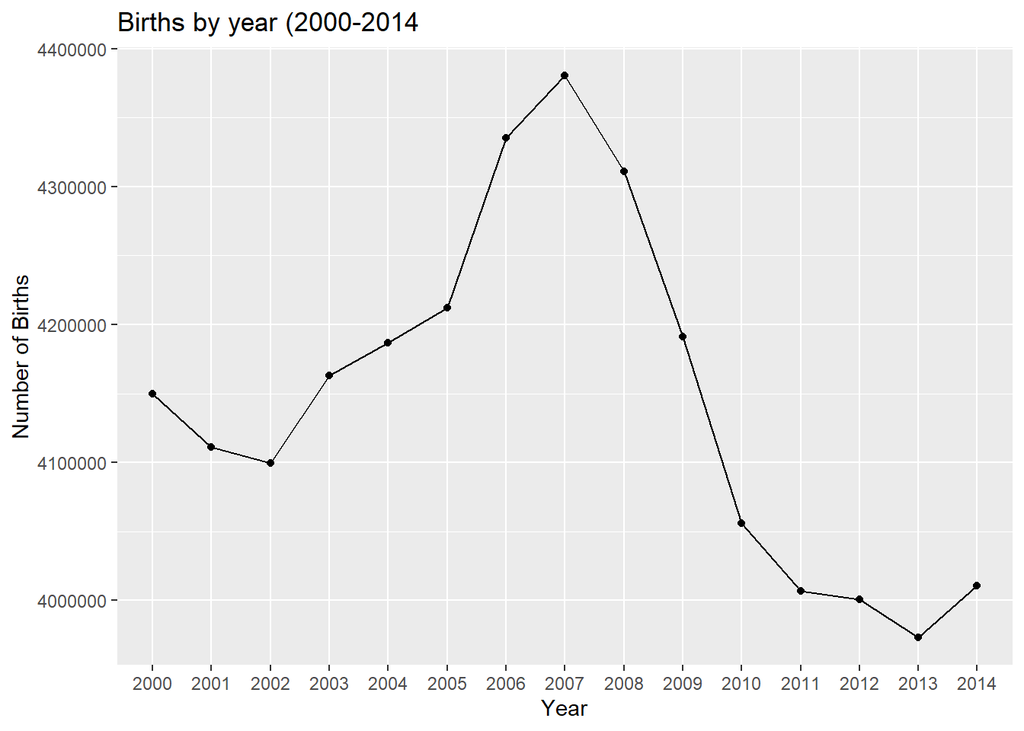

```r
ggplot(us_births_groupby, aes(x=year, y=total_year, group=1)) +
  geom_line()+
  geom_point()+
  labs(x = "Year",
       y = "Number of Births",
       title = "Births by year (2000-2014")
```

The line graphic shows more characteristics. In fact, the year 0f 2007 is the peak on total number of births, that starts decreasing on the next year (2008). The year 2010 that was identified before, is when this tendency is marked.

## Hypothesis: Friday the 13 has incidence into birth numbers.

### Babies on Fridays:

We will filter (function `filter`) births when the day of the week is “5” (Friday), and store it into a new database, observing the mean of births for this day (we can verify that its value was already observed on the first section).

```r
friday <- us_births %>%
  filter(day_of_week == '5')

mean(friday$births)
```

```
## [1] 12596.16
```

### Babies on Friday the 13:

A double filter will show us all births on Friday (day_of_week == ‘5’) and date 13 ( date_of_month == ‘13’). Lets observe the mean of births on this new database.

```r
friday13 <- us_births %>%
  filter(day_of_week == '5',
         date_of_month == '13')

mean(friday13$births)
```

```
## [1] 11949.96
```

We can also, observe the mean of births for each month as following:

```r
friday13 %>%
  group_by(month) %>%
  summarise(mean_month = mean(births),
            sd_month = sd(births))
```

```
## # A tibble: 12 × 3
##    month mean_month sd_month
##    <fct>      <dbl>    <dbl>
##  1 1         11687     434.
##  2 2         11790.     58.7
##  3 3         12087      NA
##  4 4         11320.    735.
##  5 5         11464     479.
##  6 6         12019.    372.
##  7 7         12508     625.
##  8 8         12184.    129.
##  9 9         12848.    254.
## 10 10        12176.    640.
## 11 11        11739      NA
## 12 12        11542      82.0
```

## Conclusion

> The results show a mean of 12596 when the day is Friday, and a mean of 11950 when it is Friday the 13. The difference between those means is 646 births. That could be considered as not enought significant, also considering the Mean between different months of the year. Thoes results indicate that in fact, some people could avoided this data, but their number is not significant into the general demand of hospitals.